# Tipología y Ciclo de Vida de los Datos - PRA2

Guillermo Arrizabalaga y Javier Paredero

05/2022

# Presentación

En esta práctica se elabora un caso práctico orientado a aprender a identificar los datos relevantes para un proyecto analítico y usar las herramientas de integración, limpieza, validación y análisis de las mismas.

## Objetivos

Los objetivos concretos de esta práctica son:

- Aprender a aplicar los conocimientos adquiridos y su capacidad de resolución de problemas en entornos nuevos o poco conocidos dentro de contextos más amplios o multidisciplinares.
- Saber identificar los datos relevantes y los tratamientos necesarios (integración, limpieza y validación) para llevar a cabo un proyecto analítico.
- Aprender a analizar los datos adecuadamente para abordar la información contenida en los datos.
- Identificar la mejor representación de los resultados para aportar conclusiones sobre el problema planteado en el proceso analítico.
- Actuar con los principios éticos y legales relacionados con la manipulación de datos en función del ámbito de aplicación.
- Desarrollar las habilidades de aprendizaje que les permitan continuar estudiando de un modo que tendrá que ser en gran medida autodirigido o autónomo.
- Desarrollar la capacidad de búsqueda, gestión y uso de información y recursos en el ámbito de la ciencia de datos.

## Competencias

En esta práctica se desarrollan las siguientes competencias del Master de Data Science:

- Capacidad de analizar un problema en el nivel de abstracción adecuado a cada situación y aplicar las habilidades y conocimientos adquiridos para abordarlo y resolverlo.
- Capacidad para aplicar las técnicas específicas de tratamiento de datos (integración, transformación, limpieza y validación) para su posterior análisis.

# Resolución

## Descripción del dataset

Para la realización de esta práctica hemos escogido el dataset propuesto en el enunciado de la misma llamado **Titanic: Machine Learning from Disaster**. La elección de este dataset se debe a que el dataset creado en la PRA1 tenía muy pocos registros y variables para realizar un buen estudio.

Este dataset llamado train.csv, proporciona una serie de atributos acerca de los pasajeros del Titanic. Estos atributos se utilizan para predecir realizar predicciones sobre otros, utilizando modelos de aprendizaje supervisado.

A continuación se explican los atributos que componen el dataset:

- PassengerId: Número que identifica al pasajero.
- Survived: Identifica si el pasajero sobrevivió (valor 1) o no (valor 0).
- Pclass: Idenfifica la clase del ticket como primera clase (valor 1), segunda clase (2) y tercera clase (3).
- Name: Nombre del pasajero.
- Sex: Sexo del pasajero.
- Age: Edad del pasajero.
- SibSp: Número de hermanos/cónyuges a bordo.
- Parch: Número de padres/hijos a bordo.
- Ticket: Número del ticket.
- Fare: Tarífa pagada.
- Cabin: Número de cabina.
- Embarked: Puerto donde embarcó.

Con este dataset se pretende estudiar la relación entre los atributos que influyen en mayor y menor medida a la posibilidad de supervivencia del pasajero. De esta manera podremos sacar conclusiones acerca de la diferencia entre géneros, clase social o edad a la hora de sobrevivir.

## Integración y selección

Cargamos el fichero de datos:

```r
data <- read.csv('train.csv',stringsAsFactors = FALSE)
head(data)
```

```
##   PassengerId Survived Pclass
## 1           1        0      3
## 2           2        1      1
## 3           3        1      3
## 4           4        1      1
## 5           5        0      3
## 6           6        0      3
##                                                  Name    Sex Age SibSp Parch
## 1                             Braund, Mr. Owen Harris   male  22     1     0
## 2 Cumings, Mrs. John Bradley (Florence Briggs Thayer) female  38     1     0
## 3                              Heikkinen, Miss. Laina female  26     0     0
## 4        Futrelle, Mrs. Jacques Heath (Lily May Peel) female  35     1     0
## 5                            Allen, Mr. William Henry   male  35     0     0
## 6                                    Moran, Mr. James   male  NA     0     0
##             Ticket    Fare Cabin Embarked
## 1        A/5 21171  7.2500              S
## 2         PC 17599 71.2833   C85        C
## 3 STON/O2. 3101282  7.9250              S
## 4           113803 53.1000  C123        S
## 5           373450  8.0500              S
## 6           330877  8.4583              Q
```

```r
dim(data)
```

```
## [1] 891  12
```

```r
data <- data[,c(1,2,3,5,6,7,8,12)]
str(data)
```

```
## 'data.frame':    891 obs. of  8 variables:
##  $ PassengerId: int  1 2 3 4 5 6 7 8 9 10 ...
##  $ Survived   : int  0 1 1 1 0 0 0 0 1 1 ...
##  $ Pclass     : int  3 1 3 1 3 3 1 3 3 2 ...
##  $ Sex        : chr  "male" "female" "female" "female" ...
##  $ Age        : num  22 38 26 35 35 NA 54 2 27 14 ...
##  $ SibSp      : int  1 1 0 1 0 0 0 3 0 1 ...
##  $ Parch      : int  0 0 0 0 0 0 0 1 2 0 ...
##  $ Embarked   : chr  "S" "C" "S" "S" ...
```

```r
dim(data)
```

```
## [1] 891   8
```

Estos serán los datos con los que trabajaremos.

## Limpieza de los datos

El primer paso va a ser comprobar si nuestros datos contienen valores nulos o vacíos:

```r
summary(data)
```

```
##   PassengerId       Survived          Pclass          Sex
##  Min.   :  1.0   Min.   :0.0000   Min.   :1.000   Length:891
##  1st Qu.:223.5   1st Qu.:0.0000   1st Qu.:2.000   Class :character
##  Median :446.0   Median :0.0000   Median :3.000   Mode  :character
##  Mean   :446.0   Mean   :0.3838   Mean   :2.309
##  3rd Qu.:668.5   3rd Qu.:1.0000   3rd Qu.:3.000
##  Max.   :891.0   Max.   :1.0000   Max.   :3.000
##
##       Age            SibSp           Parch          Embarked
##  Min.   : 0.42   Min.   :0.000   Min.   :0.0000   Length:891
##  1st Qu.:20.12   1st Qu.:0.000   1st Qu.:0.0000   Class :character
##  Median :28.00   Median :0.000   Median :0.0000   Mode  :character
##  Mean   :29.70   Mean   :0.523   Mean   :0.3816
##  3rd Qu.:38.00   3rd Qu.:1.000   3rd Qu.:0.0000
##  Max.   :80.00   Max.   :8.000   Max.   :6.0000
##  NA's   :177
```

La función summary ya nos revela que efectivamente existen datos nulos así que vamos a utilizar la función “is.na” para observar distintos casos:

```r
colSums(is.na(data))
```

```
## PassengerId    Survived      Pclass         Sex         Age       SibSp
##           0           0           0           0         177           0
##       Parch    Embarked
##           0           0
```

```r
colSums(data=="")
```

```
## PassengerId    Survived      Pclass         Sex         Age       SibSp
##           0           0           0           0          NA           0
##       Parch    Embarked
##           0           2
```

```r
colSums(data=="?")
```

```
## PassengerId    Survived      Pclass         Sex         Age       SibSp
##           0           0           0           0          NA           0
##       Parch    Embarked
##           0           0
```

En este caso observamos que la variable “Age” contiene 177 valores nulos y la variable “Embarked” cotiene 2. Las dos filas pertenecientes a la variable “Embarked” vamos a eliminarlas mientras las filas pertenecientes a la variable “Age” vamos a completarlas mediante un método de imputación de vecinos.

```r
if(!require(VIM)){
    install.packages('VIM', repos='http://cran.us.r-project.org')
    library(VIM)
}
```

```
## VIM is ready to use.
```

```
## Suggestions and bug-reports can be submitted at: https://github.com/statistikat/VIM/issues
```

```r
data<- data[-data$PassengerId[data$Embarked==""],]
data$Age <- kNN(data)$Age
colSums(data=="")
```

```
## PassengerId    Survived      Pclass         Sex         Age       SibSp
##           0           0           0           0           0           0
##       Parch    Embarked
##           0           0
```

```r
colSums(is.na(data))
```

```
## PassengerId    Survived      Pclass         Sex         Age       SibSp
##           0           0           0           0           0           0
##       Parch    Embarked
##           0           0
```

```r
dim(data)
```

```
## [1] 889   8
```

De esta manera ya no tenemos valores nulos en nuestros datos. El siguiente paso es ver si tenemos valores extremos. Para ello vamos a representar las variables numéricas:

```r
if(!require(ggpubr)){
    install.packages('ggpubr', repos='http://cran.us.r-project.org')
    library(ggpubr)
}
```

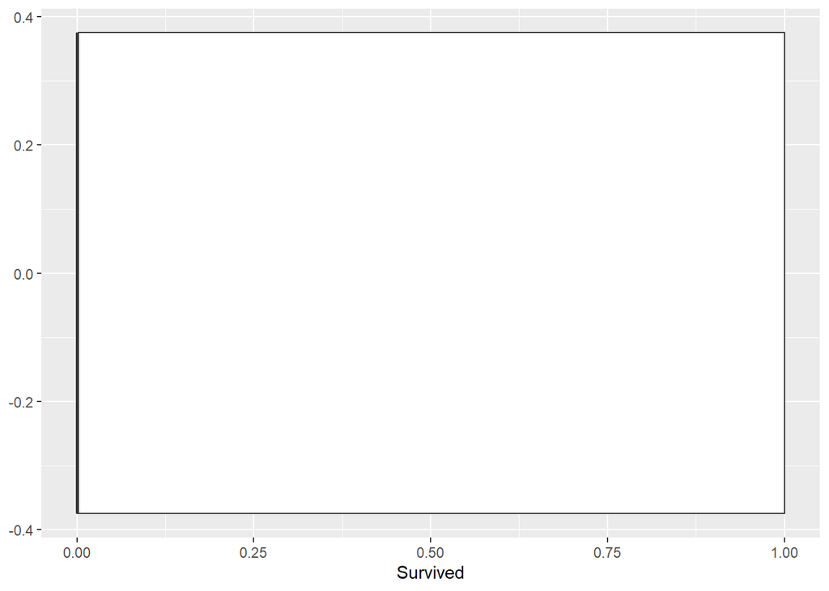

```r
if(!require(ggplot2)){
    install.packages('ggplot2', repos='http://cran.us.r-project.org')
    library(ggplot2)
}

ggplot(data,aes(Survived))+geom_boxplot()
```

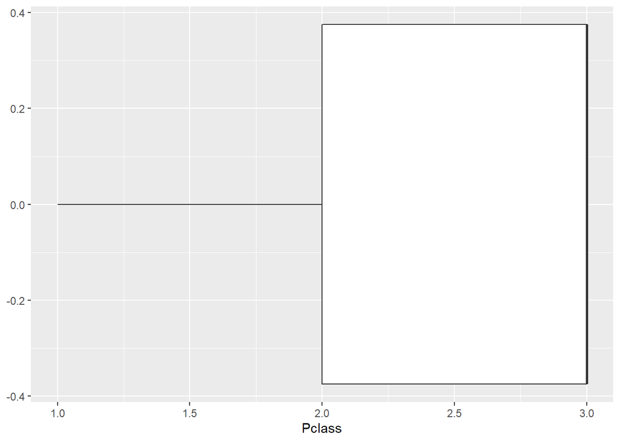

```r
ggplot(data,aes(Pclass))+geom_boxplot()
```

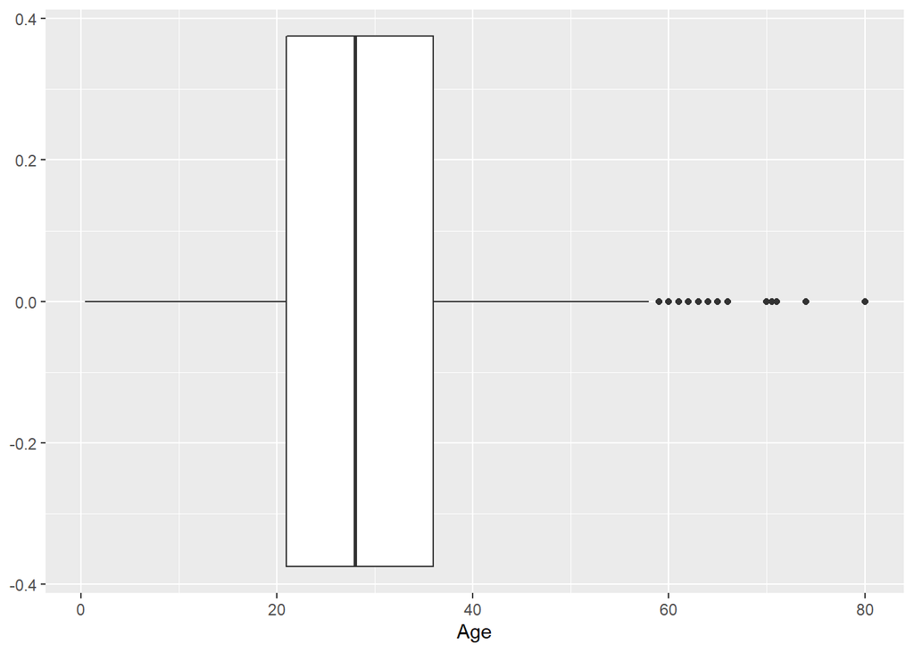

```r
ggplot(data,aes(Age))+geom_boxplot()
```

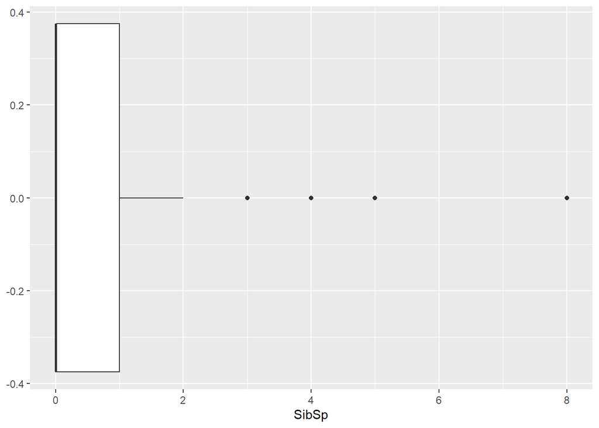

```r
ggplot(data,aes(SibSp))+geom_boxplot()
```

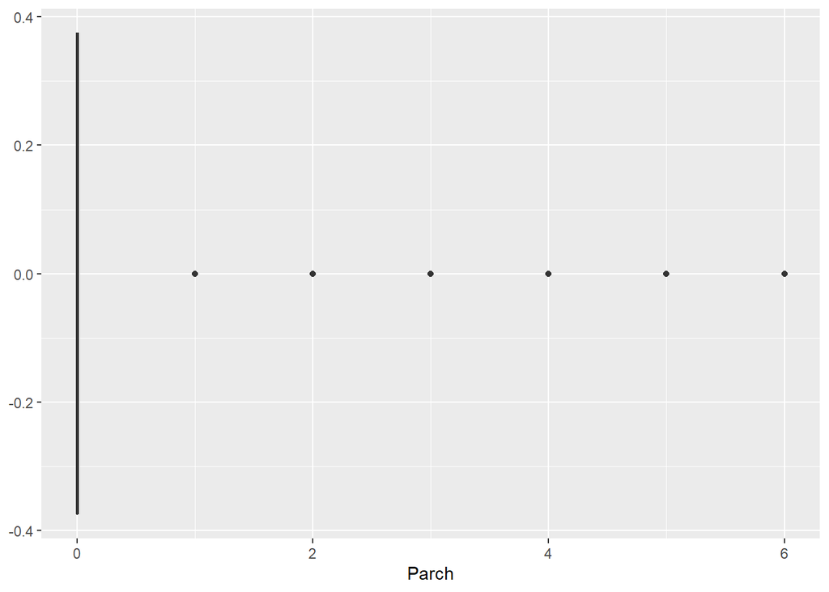

```r
ggplot(data,aes(Parch))+geom_boxplot()
```

En el caso las variables “SibSp”, “Parch” y “Age” tienen valores extremos pero no los eliminamos puesto que son valores reales que serán útiles para nuestro modelo. Lo que vamos a hacer es discretizar la variable edad para facilitar su uso:

```r
data["Age_d"] <- cut(data$Age, breaks = c(0,16,32,48,64,81), labels = c("0-15","16-31", "32-47", "48-63", "64-80"))
```

Esto nos ayudará con los análisis futuros.

Una vez tenemos los datos limpios, los guardamos en un nuevo CSV:

```r
write.csv(data, "titanic_clean.csv")
```

## Análisis de los datos

Comenzamos realizando un análisis exploratorio de los datos. Esto nos ayudará a ver de forma gráfica nuestros datos y a sacar unas primeras conclusiones.

```r
if(!require(grid)){
    install.packages('grid', repos='http://cran.us.r-project.org')
    library(grid)
}
if(!require(gridExtra)){
    install.packages('gridExtra', repos='http://cran.us.r-project.org')
    library(gridExtra)
}
```

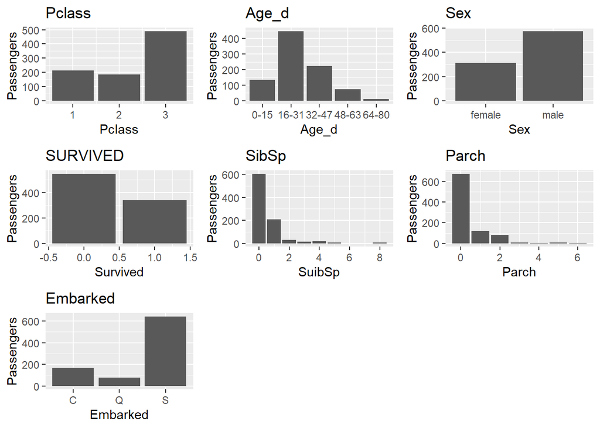

```r
grid.newpage()

plotClass<-ggplot(data,aes(Pclass))+geom_bar() +labs(x="Pclass", y="Passengers")+ guides(fill=guide_legend(title=""))+ scale_fill_manual(values=c("blue","#008000"))+ggtitle("Pclass")

plotAge_d<-ggplot(data,aes(Age_d))+geom_bar() +labs(x="Age_d", y="Passengers")+ guides(fill=guide_legend(title=""))+ scale_fill_manual(values=c("blue","#008000"))+ggtitle("Age_d")

plotSex<-ggplot(data,aes(Sex))+geom_bar() +labs(x="Sex", y="Passengers")+ guides(fill=guide_legend(title=""))+ scale_fill_manual(values=c("blue","#008000"))+ggtitle("Sex")

plotSurvived<-ggplot(data,aes(Survived))+geom_bar() +labs(x="Survived", y="Passengers")+ guides(fill=guide_legend(title=""))+ scale_fill_manual(values=c("blue","#008000"))+ggtitle("SURVIVED")

plotSibSp<-ggplot(data,aes(SibSp))+geom_bar() +labs(x="SuibSp", y="Passengers")+ guides(fill=guide_legend(title=""))+ scale_fill_manual(values=c("blue","#008000"))+ggtitle("SibSp")

plotParch<-ggplot(data,aes(Parch))+geom_bar() +labs(x="Parch", y="Passengers")+ guides(fill=guide_legend(title=""))+ scale_fill_manual(values=c("blue","#008000"))+ggtitle("Parch")

plotEmbarked<-ggplot(data,aes(Embarked))+geom_bar() +labs(x="Embarked", y="Passengers")+ guides(fill=guide_legend(title=""))+ scale_fill_manual(values=c("blue","#008000"))+ggtitle("Embarked")

grid.arrange(plotClass,plotAge_d,plotSex,plotSurvived,plotSibSp,plotParch,plotEmbarked,ncol=3)
```

Así a simpple vista podemos observar que la mayoría de los pasajeros se concentra entre los 16 y los 32 años. También podemos deducir que la mayoría son de tercera clase, y que hay más población de hombres que de mujeres.

El siguiente paso va a ser estudiar la relación de las variables con la variable que se va a predecir, el este caso “Survived”. Para ello será necesario transformar las variables a factores. Además vamos a prescindir de la variable Parch y SibSp ya que la gran mayoría de sus casos se concentran en 0:

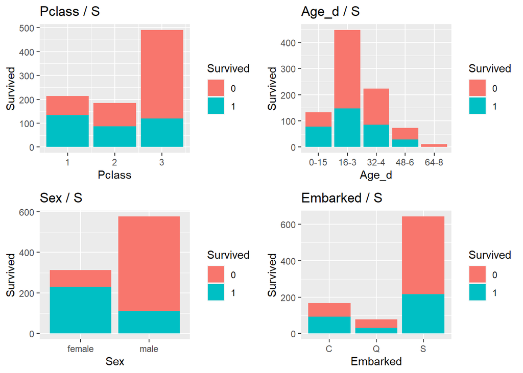

```r
data$Survived <- factor(data$Survived, levels=c("0","1"))
grid.newpage()

plotClass<-ggplot(data,aes(Pclass, fill=Survived))+geom_bar() +labs(x="Pclass", y="Survived")+ggtitle("Pclass / S")

plotAge_d<-ggplot(data,aes(Age_d, fill=Survived))+geom_bar() +labs(x="Age_d", y="Survived")+ggtitle("Age_d / S")+scale_x_discrete(labels = abbreviate)

plotSex<-ggplot(data,aes(Sex, fill=Survived))+geom_bar() +labs(x="Sex", y="Survived")+ggtitle("Sex / S")

plotEmbarked<-ggplot(data,aes(Embarked, fill=Survived))+geom_bar() +labs(x="Embarked", y="Survived")+ggtitle("Embarked / S")

grid.arrange(plotClass,plotAge_d,plotSex,plotEmbarked,ncol=2)
```

Podemos observar como la mayoría de muertos se concentran en la tercera clase, esto posiblemente por su condición, ya que es probable que a la hora de evacuar, tuvieran preferencia los de las clases más altas. Además podemos observar como la gran mayoría de muertos se concentra en los hombres, con mucho más del 50%.

A continuación vamos a realizar unos test de significacia para ver cuales de los atributos tienen mayor influencia con la variable a predecir. Esto nos ayudará a aumentar la precisión en la predicción y a reducir el sobreentrenamiento al contar con menos datos engañosos. Los escogidos van a se el cálculo de la V de Cramér y el coeficiente de Phi:

```r
if(!require(DescTools)){
    install.packages('DescTools', repos='http://cran.us.r-project.org')
    library(DescTools)
}
tabla_CS <- table(data$Pclass,data$Survived)
CramerV(tabla_CS)
```

```
## [1] 0.3370293
```

```r
Phi(tabla_CS)
```

```
## [1] 0.3370293
```

```r
tabla_AS <- table(data$Age_d,data$Survived)
CramerV(tabla_AS)
```

```
## [1] 0.1928751
```

```r
Phi(tabla_AS)
```

```
## [1] 0.1928751
```

```r
tabla_SS <- table(data$Sex,data$Survived)
CramerV(tabla_SS)
```

```
## [1] 0.5415849
```

```r
Phi(tabla_SS)
```

```
## [1] 0.5415849
```

```r
tabla_ES <- table(data$Embarked,data$Survived)
CramerV(tabla_ES)
```

```
## [1] 0.1726168
```

```r
Phi(tabla_ES)
```

```
## [1] 0.1726168
```

```r
tabla_SiS <- table(data$SibSp,data$Survived)
CramerV(tabla_SiS)
```

```
## [1] 0.206043
```

```r
Phi(tabla_SiS)
```

```
## [1] 0.206043
```

```r
tabla_PS <- table(data$Parch,data$Survived)
CramerV(tabla_PS)
```

```
## [1] 0.1787364
```

```r
Phi(tabla_PS)
```

```
## [1] 0.1787364
```

En este caso como no tenemos ningún valor inferior a 0.1, vamos a conservar todas las variables que tenemos en este dataset.

## Comprobación de la normalidad y homogeneidad de la varianza

Para comprobar si nuestras variables siguen una distribución normal, vamos a realizar la prueba de Anderson-Darling. Con esta prueba se obtiene un p-valor. Si este es superior al valor alfa prefijado, se considera que la variable sigue una distribución normal:

```r
if(!require(nortest)){
    install.packages('nortest', repos='http://cran.us.r-project.org')
    library(nortest)
}
alpha = 0.05
col.names = colnames(data)
for (i in 1:ncol(data)) {
if (i == 1) cat("Variables que no siguen una distribución normal:\n")
if (is.integer(data[,i]) | is.numeric(data[,i])) {
p_val = ad.test(data[,i])$p.value
if (p_val < alpha) {
cat(col.names[i])
# Format output
if (i < ncol(data) - 1) cat(", ")
if (i %% 3 == 0) cat("\n")
}
}
}
```

```
## Variables que no siguen una distribución normal:
## PassengerId, Pclass,
## Age, SibSp,
## Parch,
```

En este caso ninguna de nuestras variables sigue una distribución normal.

En cuanto a la homogeneidad de la varianza, utilizaremos el test de Fligner-Killeen, que se trata de la alternativa no paramétrica del test de Leneve, utilizada cuando los datos no cumplen con la condición de normalidad:

```r
fligner.test(Pclass ~ Survived, data = data)
```

```
##
##  Fligner-Killeen test of homogeneity of variances
##
## data:  Pclass by Survived
## Fligner-Killeen:med chi-squared = 23.369, df = 1, p-value = 1.337e-06
```

```r
fligner.test(SibSp ~ Survived, data = data)
```

```
##
##  Fligner-Killeen test of homogeneity of variances
##
## data:  SibSp by Survived
## Fligner-Killeen:med chi-squared = 1.3696, df = 1, p-value = 0.2419
```

```r
fligner.test(Parch ~ Survived, data = data)
```

```
##
##  Fligner-Killeen test of homogeneity of variances
##
## data:  Parch by Survived
## Fligner-Killeen:med chi-squared = 11.57, df = 1, p-value = 0.0006704
```

Para aquellas variables en que el test es aplicable, hemos de tener en cuenta que aquellas que tienen un p-valor inferior al nivel de signficancia (< 0.05) se debe rechazar la hipótesis nula de homocesticidad, de modo que tanto “Pclass” como “Parch” presentan varianzas estadísticamente diferentes para distintos grupos de “Survived”. Por contra, en el caso de “SibSp” sí presenta varianzas estadísticamenes similares para diferentes grupos de “Survived”.

## Aplicación de pruebas estadísticas para comparar los grupos de datos

En primer lugar, aplicamos regresión lineal, un modelo matemático que tiene como objetivo aproximar la relación de dependencia lineal entre una variable dependiente y una serie de variables independientes.

```r
m1 = lm(Pclass ~ Survived, data = data)
summary(m1)
```

```
##
## Call:
## lm(formula = Pclass ~ Survived, data = data)
##
## Residuals:
##     Min      1Q  Median      3Q     Max
## -1.5319 -0.5319  0.4681  0.4681  1.0441
##
## Coefficients:
##             Estimate Std. Error t value Pr(>|t|)
## (Intercept)  2.53188    0.03358   75.40   <2e-16 ***
## Survived1   -0.57599    0.05430  -10.61   <2e-16 ***
## ---
## Signif. codes:  0 '***' 0.001 '**' 0.01 '*' 0.05 '.' 0.1 ' ' 1
##
## Residual standard error: 0.7867 on 887 degrees of freedom
## Multiple R-squared:  0.1126, Adjusted R-squared:  0.1116
## F-statistic: 112.5 on 1 and 887 DF,  p-value: < 2.2e-16
```

```r
m2 = lm(SibSp ~ Survived, data = data)
summary(m2)
```

```
##
## Call:
## lm(formula = SibSp ~ Survived, data = data)
##
## Residuals:
##     Min      1Q  Median      3Q     Max
## -0.5537 -0.5537 -0.4765  0.4463  7.4463
##
## Coefficients:
##             Estimate Std. Error t value Pr(>|t|)
## (Intercept)  0.55373    0.04710  11.756   <2e-16 ***
## Survived1   -0.07726    0.07617  -1.014    0.311
## ---
## Signif. codes:  0 '***' 0.001 '**' 0.01 '*' 0.05 '.' 0.1 ' ' 1
##
## Residual standard error: 1.104 on 887 degrees of freedom
## Multiple R-squared:  0.001159,   Adjusted R-squared:  3.263e-05
## F-statistic: 1.029 on 1 and 887 DF,  p-value: 0.3107
```

```r
m3 = lm(Parch ~ Survived, data = data)
summary(m3)
```

```
##
## Call:
## lm(formula = Parch ~ Survived, data = data)
##
## Residuals:
##     Min      1Q  Median      3Q     Max
## -0.4676 -0.4676 -0.3297 -0.3297  5.6703
##
## Coefficients:
##             Estimate Std. Error t value Pr(>|t|)
## (Intercept)  0.32969    0.03433   9.603   <2e-16 ***
## Survived1    0.13796    0.05551   2.485   0.0131 *
## ---
## Signif. codes:  0 '***' 0.001 '**' 0.01 '*' 0.05 '.' 0.1 ' ' 1
##
## Residual standard error: 0.8044 on 887 degrees of freedom
## Multiple R-squared:  0.006914,   Adjusted R-squared:  0.005794
## F-statistic: 6.175 on 1 and 887 DF,  p-value: 0.01314
```

Siendo el coeficiente de determinación (R-squared) una medida de calidad del modelo, que toma valores entre 0 y 1. Si este valor es alto, indica una fuerte correlación entre ambas variables, que no se da en ninguno de los casos presentados aquí.

Otro método es el coeficiente de correlación, que mide la asociación entre dos variables. Puede tomar valores entre -1 y 1, donde los extremos indican una correlación perfecta, y el 0 indica ausencia de correlación. El signo es negativo cuando los valores elevados de una variable se asocian con valores pequeños de la otra, y es positivo cuando ambas variables tienden a incrementar o disminuir simultáneamente. El coeficiente de correlación más utilizado es el de Pearson, pero requiere que la distribución de las dos variables comparadas sea normal, y además que se cumpla el criterio de homocedasticidad. Por tanto, en nuestro caso tenemos que optar por la correlación de Spearman, que aparece como alternativa no paramétrica que mide el grado de dependencia entre dos variables. En este caso, lo aplicamos entre las variables numéricas de nuestro estudio:

```r
cor.test(data$Pclass, data$Parch, method = "spearman")
```

```
##
##  Spearman's rank correlation rho
##
## data:  data$Pclass and data$Parch
## S = 119990962, p-value = 0.4621
## alternative hypothesis: true rho is not equal to 0
## sample estimates:
##         rho
## -0.02469603
```

```r
cor.test(data$Pclass, data$SibSp, method = "spearman")
```

```
##
##  Spearman's rank correlation rho
##
## data:  data$Pclass and data$SibSp
## S = 122401219, p-value = 0.1774
## alternative hypothesis: true rho is not equal to 0
## sample estimates:
##         rho
## -0.04527908
```

```r
cor.test(data$Parch, data$SibSp, method = "spearman")
```

```
##
##  Spearman's rank correlation rho
##
## data:  data$Parch and data$SibSp
## S = 64450483, p-value < 2.2e-16
## alternative hypothesis: true rho is not equal to 0
## sample estimates:
##       rho
## 0.4496073
```

Siendo la correlación más elevada entre las variables “Parch” y “SibSp”, y nula en resto de comparaciones.

Por último, podemos proceder a la generación de un árbol de decisión, que nos permita extraer conclusiones que nos permitan inferir cuales son las características base de los pasajeros en relación con su índice de supervivencia. Veámoslo:

[figure not shown]

```r
if(!require(rpart.plot)){
    install.packages('rpart.plot', repos='http://cran.us.r-project.org')
    library(rpart.plot)
}
tree <- rpart(Survived ~ Pclass + Sex + Age + SibSp + Parch + Embarked, data=data, method="class")
plot(tree)
text(tree, cex=1)
```

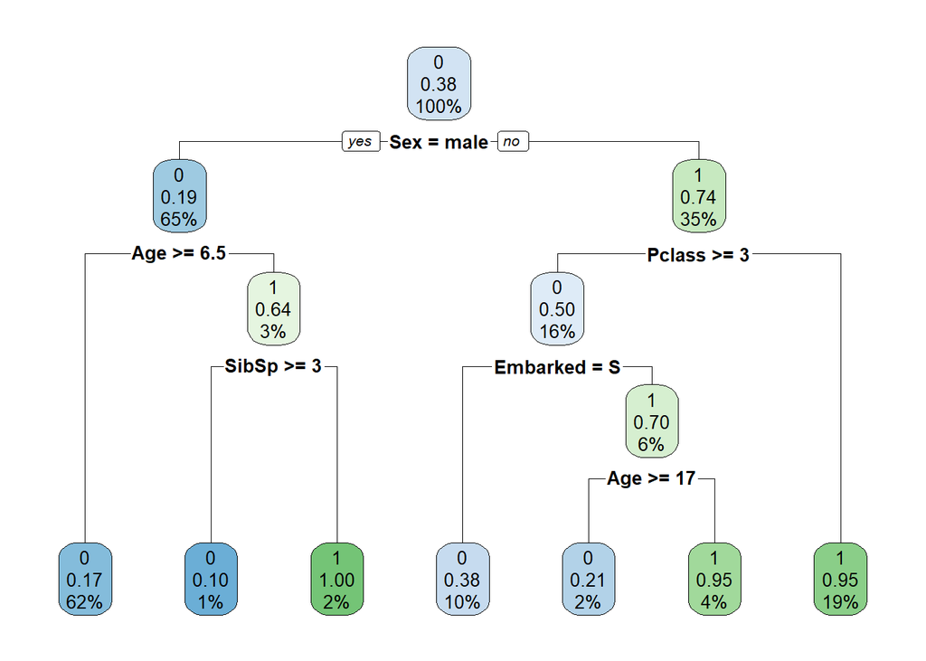

```r
rpart.plot(tree)
```

Lo cual ya nos ofrece un resultado mucho más interesante para inferir la supervivencia a partir de ciertos atributos de los pasajeros.